# Lecture4 Notes: Data Wrangling

Wenjie Qi

2021/10/3

## Tabular data

```r
library(tidyverse)
library(palmerpenguins)
```

Rows: examples, observations, cases Columns: features, variables, covariates

```r
head(penguins)
```

```
## # A tibble: 6 x 8
##   species island bill_length_mm bill_depth_mm flipper_length_~ body_mass_g sex
##   <fct>   <fct>           <dbl>         <dbl>            <int>       <int> <fct>
## 1 Adelie  Torge~           39.1          18.7              181        3750 male
## 2 Adelie  Torge~           39.5          17.4              186        3800 fema~
## 3 Adelie  Torge~           40.3          18                195        3250 fema~
## 4 Adelie  Torge~           NA            NA                 NA          NA <NA>
## 5 Adelie  Torge~           36.7          19.3              193        3450 fema~
## 6 Adelie  Torge~           39.3          20.6              190        3650 male
## # ... with 1 more variable: year <int>
```

# Data Wrangling

Data wrangling is the process of transforming data from one form to another Extracting, transforming, fusing and aggregating information from exist data We can do this all in R with the Tidyverse, especialling the dplyr

### “nouns”

Data frames, the representations in R of tabular data

### “verbs”

Operations which can be applied to data frames select() - take a subset of columns filter() - take s subset of rows mutate() - add or modify existing columns arrange() - sort rows summarize()- aggregate data across existing rows

## select()

extract a subset of columns

```r
select(penguins, species, bill_length_mm, body_mass_g)
```

```
## # A tibble: 344 x 3
##    species bill_length_mm body_mass_g
##    <fct>            <dbl>       <int>
##  1 Adelie            39.1        3750
##  2 Adelie            39.5        3800
##  3 Adelie            40.3        3250
##  4 Adelie            NA            NA
##  5 Adelie            36.7        3450
##  6 Adelie            39.3        3650
##  7 Adelie            38.9        3625
##  8 Adelie            39.2        4675
##  9 Adelie            34.1        3475
## 10 Adelie            42          4250
## # ... with 334 more rows
```

remove several columns: put a minus before arguments

```r
select(penguins, -species, -bill_length_mm, -body_mass_g)
```

```
## # A tibble: 344 x 5
##    island    bill_depth_mm flipper_length_mm sex     year
##    <fct>             <dbl>             <int> <fct>  <int>
##  1 Torgersen          18.7               181 male    2007
##  2 Torgersen          17.4               186 female  2007
##  3 Torgersen          18                 195 female  2007
##  4 Torgersen          NA                  NA <NA>    2007
##  5 Torgersen          19.3               193 female  2007
##  6 Torgersen          20.6               190 male    2007
##  7 Torgersen          17.8               181 female  2007
##  8 Torgersen          19.6               195 male    2007
##  9 Torgersen          18.1               193 <NA>    2007
## 10 Torgersen          20.2               190 <NA>    2007
## # ... with 334 more rows
```

## filter()

extract a subset of rows

```r
filter(penguins, species=="Gentoo")
```

```
## # A tibble: 124 x 8
##    species island bill_length_mm bill_depth_mm flipper_length_mm body_mass_g
##    <fct>   <fct>           <dbl>         <dbl>             <int>       <int>
##  1 Gentoo  Biscoe           46.1          13.2               211        4500
##  2 Gentoo  Biscoe           50            16.3               230        5700
##  3 Gentoo  Biscoe           48.7          14.1               210        4450
##  4 Gentoo  Biscoe           50            15.2               218        5700
##  5 Gentoo  Biscoe           47.6          14.5               215        5400
##  6 Gentoo  Biscoe           46.5          13.5               210        4550
##  7 Gentoo  Biscoe           45.4          14.6               211        4800
##  8 Gentoo  Biscoe           46.7          15.3               219        5200
##  9 Gentoo  Biscoe           43.3          13.4               209        4400
## 10 Gentoo  Biscoe           46.8          15.4               215        5150
## # ... with 114 more rows, and 2 more variables: sex <fct>, year <int>
```

we can combine two or more conditions

```r
filter(penguins, species=="Gentoo" & body_mass_g>5000)
```

```
## # A tibble: 61 x 8
##    species island bill_length_mm bill_depth_mm flipper_length_mm body_mass_g
##    <fct>   <fct>           <dbl>         <dbl>             <int>       <int>
##  1 Gentoo  Biscoe           50            16.3               230        5700
##  2 Gentoo  Biscoe           50            15.2               218        5700
##  3 Gentoo  Biscoe           47.6          14.5               215        5400
##  4 Gentoo  Biscoe           46.7          15.3               219        5200
##  5 Gentoo  Biscoe           46.8          15.4               215        5150
##  6 Gentoo  Biscoe           49            16.1               216        5550
##  7 Gentoo  Biscoe           48.4          14.6               213        5850
##  8 Gentoo  Biscoe           49.3          15.7               217        5850
##  9 Gentoo  Biscoe           49.2          15.2               221        6300
## 10 Gentoo  Biscoe           48.7          15.1               222        5350
## # ... with 51 more rows, and 2 more variables: sex <fct>, year <int>
```

we can combing select() and filter()

```r
select(filter(penguins, species=="Gentoo"), species, bill_length_mm, body_mass_g)
```

```
## # A tibble: 124 x 3
##    species bill_length_mm body_mass_g
##    <fct>            <dbl>       <int>
##  1 Gentoo            46.1        4500
##  2 Gentoo            50          5700
##  3 Gentoo            48.7        4450
##  4 Gentoo            50          5700
##  5 Gentoo            47.6        5400
##  6 Gentoo            46.5        4550
##  7 Gentoo            45.4        4800
##  8 Gentoo            46.7        5200
##  9 Gentoo            43.3        4400
## 10 Gentoo            46.8        5150
## # ... with 114 more rows
```

## The pip operator “%>%”

chaining multiple operations with the pip operator %>%

```r
penguins %>%
  filter(species=="Gentoo") %>%
  select(species, bill_length_mm, body_mass_g)
```

```
## # A tibble: 124 x 3
##    species bill_length_mm body_mass_g
##    <fct>            <dbl>       <int>
##  1 Gentoo            46.1        4500
##  2 Gentoo            50          5700
##  3 Gentoo            48.7        4450
##  4 Gentoo            50          5700
##  5 Gentoo            47.6        5400
##  6 Gentoo            46.5        4550
##  7 Gentoo            45.4        4800
##  8 Gentoo            46.7        5200
##  9 Gentoo            43.3        4400
## 10 Gentoo            46.8        5150
## # ... with 114 more rows
```

%>% allow arguments to be implicitly passed as object to the function after the pip

```r
f <- function(a,b){
  return(a^2 + b)
}
f(3,1)
```

```
## [1] 10
```

```r
3 %>% f(1)  # "3" is supplied as the first argument in the function
```

```
## [1] 10
```

## mutate()

create a new column as a function of existing columns

```r
my_penguins <- penguins %>%
  mutate(flipper_bill_ratio = flipper_length_mm/bill_length_mm) %>%
  select(species, bill_length_mm, flipper_length_mm, flipper_bill_ratio)
my_penguins
```

```
## # A tibble: 344 x 4
##    species bill_length_mm flipper_length_mm flipper_bill_ratio
##    <fct>            <dbl>             <int>              <dbl>
##  1 Adelie            39.1               181               4.63
##  2 Adelie            39.5               186               4.71
##  3 Adelie            40.3               195               4.84
##  4 Adelie            NA                  NA              NA
##  5 Adelie            36.7               193               5.26
##  6 Adelie            39.3               190               4.83
##  7 Adelie            38.9               181               4.65
##  8 Adelie            39.2               195               4.97
##  9 Adelie            34.1               193               5.66
## 10 Adelie            42                 190               4.52
## # ... with 334 more rows
```

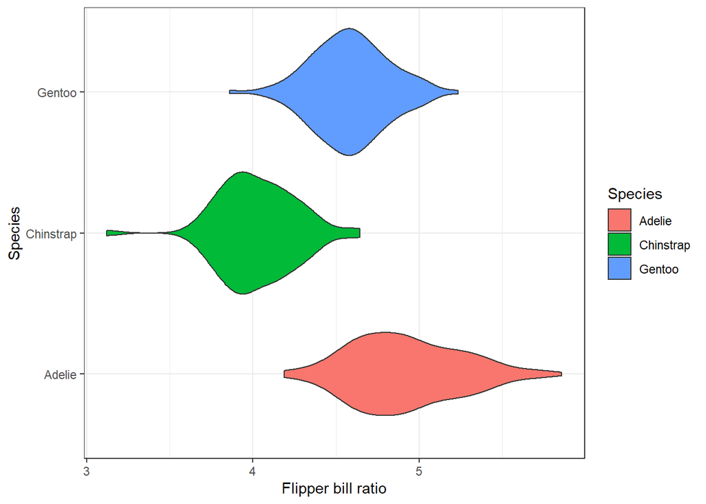

```r
ggplot(data=rename(my_penguins, Species=species), aes(x=flipper_bill_ratio, y=Species, fill=Species)) + geom_violin() + theme_bw() + xlab("Flipper bill ratio")
```

## rename()

```r
my_penguins %>% rename(f_over_b = flipper_bill_ratio)
```

```
## # A tibble: 344 x 4
##    species bill_length_mm flipper_length_mm f_over_b
##    <fct>            <dbl>             <int>    <dbl>
##  1 Adelie            39.1               181     4.63
##  2 Adelie            39.5               186     4.71
##  3 Adelie            40.3               195     4.84
##  4 Adelie            NA                  NA    NA
##  5 Adelie            36.7               193     5.26
##  6 Adelie            39.3               190     4.83
##  7 Adelie            38.9               181     4.65
##  8 Adelie            39.2               195     4.97
##  9 Adelie            34.1               193     5.66
## 10 Adelie            42                 190     4.52
## # ... with 334 more rows
```

## arrange()

sort the rows of a table via arrange()

```r
my_penguins %>% arrange(desc(bill_length_mm))
```

```
## # A tibble: 344 x 4
##    species   bill_length_mm flipper_length_mm flipper_bill_ratio
##    <fct>              <dbl>             <int>              <dbl>
##  1 Gentoo              59.6               230               3.86
##  2 Chinstrap           58                 181               3.12
##  3 Gentoo              55.9               228               4.08
##  4 Chinstrap           55.8               207               3.71
##  5 Gentoo              55.1               230               4.17
##  6 Gentoo              54.3               231               4.25
##  7 Chinstrap           54.2               201               3.71
##  8 Chinstrap           53.5               205               3.83
##  9 Gentoo              53.4               219               4.10
## 10 Chinstrap           52.8               205               3.88
## # ... with 334 more rows
```

## summarize()

summarize() computes vector functions across the entire data frame

```r
penguins %>%
  summarize(
    num_rows=n(), avg_weights_kg=mean(body_mass_g/1000, na.rm=T), avg_flipper_bill_ratio=mean(flipper_length_mm/bill_length_mm, na.rm=T)
  )
```

```
## # A tibble: 1 x 3
##   num_rows avg_weights_kg avg_flipper_bill_ratio
##      <int>          <dbl>                  <dbl>
## 1      344           4.20                   4.62
```

combine summarize() and group_by()

```r
penguins %>%
  group_by(species) %>%
  summarize(
    num_rows=n(), avg_weight_kg=mean(body_mass_g/1000,na.rm=T), avg_flipper_bill_ratio=mean(flipper_length_mm/bill_length_mm,na.rm=T)
  )
```

```
## # A tibble: 3 x 4
##   species   num_rows avg_weight_kg avg_flipper_bill_ratio
##   <fct>        <int>         <dbl>                  <dbl>
## 1 Adelie         152          3.70                   4.92
## 2 Chinstrap       68          3.73                   4.02
## 3 Gentoo         124          5.08                   4.58
```

## across()

apply a function within summarize to all columns at once

```r
# summarize(penguins, across(everything(), ~sum(is.na(.x))))
penguins %>%
  summarize(across(everything(), ~sum(is.na(.x))))
```

```
## # A tibble: 1 x 8
##   species island bill_length_mm bill_depth_mm flipper_length_~ body_mass_g   sex
##     <int>  <int>          <int>         <int>            <int>       <int> <int>
## 1       0      0              2             2                2           2    11
## # ... with 1 more variable: year <int>
```

## across() with where()

```r
penguins %>%
  summarize(across(where(is.numeric), ~mean(.x, na.rm=T)))
```

```
## # A tibble: 1 x 5
##   bill_length_mm bill_depth_mm flipper_length_mm body_mass_g  year
##            <dbl>         <dbl>             <dbl>       <dbl> <dbl>
## 1           43.9          17.2              201.       4202. 2008.
```

## Combining summarize(), group_by() and across()

```r
penguins %>%
  select(-year) %>%
  group_by(species) %>%
  summarize(across(where(is.numeric), ~mean(.x, na.rm=T)), num_rows=n())
```

```
## # A tibble: 3 x 6
##   species   bill_length_mm bill_depth_mm flipper_length_mm body_mass_g num_rows
##   <fct>              <dbl>         <dbl>             <dbl>       <dbl>    <int>
## 1 Adelie              38.8          18.3              190.       3701.      152
## 2 Chinstrap           48.8          18.4              196.       3733.       68
## 3 Gentoo              47.5          15.0              217.       5076.      124
```

## join()

fuse multiple data frames

```r
penguin_bill_lengths_df <- penguins %>%
  arrange(desc(bill_length_mm)) %>%
  select(species, bill_length_mm)
penguin_bill_lengths_df
```

```
## # A tibble: 344 x 2
##    species   bill_length_mm
##    <fct>              <dbl>
##  1 Gentoo              59.6
##  2 Chinstrap           58
##  3 Gentoo              55.9
##  4 Chinstrap           55.8
##  5 Gentoo              55.1
##  6 Gentoo              54.3
##  7 Chinstrap           54.2
##  8 Chinstrap           53.5
##  9 Gentoo              53.4
## 10 Chinstrap           52.8
## # ... with 334 more rows
```

```r
species <- unique(penguins$species)
latin_name <- c("Pygoscelis adeliae", "Pygoscelis papua", "Pygoscelis antarcticus")
latin_name_df <- data.frame(species, latin_name)
latin_name_df
```

```
##     species             latin_name
## 1    Adelie     Pygoscelis adeliae
## 2    Gentoo       Pygoscelis papua
## 3 Chinstrap Pygoscelis antarcticus
```

```r
penguin_bill_lengths_df %>%
  inner_join(latin_name_df)
```

```
## # A tibble: 344 x 3
##    species   bill_length_mm latin_name
##    <fct>              <dbl> <chr>
##  1 Gentoo              59.6 Pygoscelis papua
##  2 Chinstrap           58   Pygoscelis antarcticus
##  3 Gentoo              55.9 Pygoscelis papua
##  4 Chinstrap           55.8 Pygoscelis antarcticus
##  5 Gentoo              55.1 Pygoscelis papua
##  6 Gentoo              54.3 Pygoscelis papua
##  7 Chinstrap           54.2 Pygoscelis antarcticus
##  8 Chinstrap           53.5 Pygoscelis antarcticus
##  9 Gentoo              53.4 Pygoscelis papua
## 10 Chinstrap           52.8 Pygoscelis antarcticus
## # ... with 334 more rows
```

### Types of join function

1. inner join: only fuse the rows appears in both data frames
2. full join: opposite of inner join
3. left join: contain all rows of the left data frame
4. right join: opposite of left join